# Worksheet 4: Data Visualization

Lane Riggs

Feb. 28, 2023

*This is the fourth in a series of worksheets for History 8510 at Clemson University. The goal of these worksheets is simple: practice, practice, practice. The worksheet introduces concepts and techniques and includes prompts for you to practice in this interactive document. When you are finished, you should change the author name (above), knit your document, and upload it to canvas. Don’t forget to commit your changes as you go and push to github when you finish the worksheet.*

## Charts and Graphs with `ggplot2()`

An essential element of working with data is trying to make sense of it and communicate your findings. Frequently, the way to do that is through some kind of data visualization. This week we are going to think about how to represent information graphically. How can we highlight patterns and trends in data in a way that helps ourselves and our readers/users understand historical data?

R has many visualization packages but the most powerful of those is `ggplot()` which builds on the concept of a grammar of graphics. To quote Hadley Wickham, “A grammar of graphics is a tool that enables us to concisely describe the components of a graphic. Such a grammar allows us to move beyond named graphics (e.g., the `scatterplot`) and gain insight into the deep structure that underlies statistical graphics.” In other words, `ggplot()` provides a set of tools to map data to visual elements on a plot, to specify the type of plot, and to control the fine details of how that plot will be displayed.

What does that mean in practice?

Any type of plot in R has 3 necessary layers.

**1) Data:** A data frame with one or more variables, each one with one or more observations.

**2) Aesthetic:** A mapping of one or more variables to one or more visual elements on the graph. For example, you could map a variable to the x-axis, another variable to the y-axis, and a categorical variable to color so that different categories get plotted with different colors.

**3) Geometry:** The type or shape of the visual elements on the graph. For example, this could be a point in the case of a scatter plot, a bar in the case of a bar plot, or a line in the case of a line plot.

Lets load all the libraries we’ll use in this worksheet:

```r
library(gapminder) #this is a dataset
library(ggplot2)
library(tidyverse)
library(DigitalMethodsData)
```

To begin, we’re going to use one of R’s built in datasets. First lets take a look at the data:

```r
data(gapminder)
```

1. Take a look at the data. What can you say about it?

> > It has six variables: country, year, life expectancy, population, continent, and GDP per capita. It’s a long dataset. It has multiple entries, or rows, for each country based on the years. These are the years: 1952, 1957, 1962, 1967, 1972, 1977, 1982, and on until 2007. The countries are listed as factors.

This data includes variables for life exptenency and per capita GDP. Lets say we want to plot these two variables against each other for all country-years within the dataset. First we have to tell `ggplot()` what our data is.

```r
p <- ggplot(data = gapminder)
```

What happened here? A new variable, `p` was created but we didn’t get a plot yet. That is because we’ve told `ggplot` what data we’re going to use but we haven’t mapped anything to a plot yet. We need to tell `ggplot` what variables in the data should be represented by which visual elements in the plot. We also haven’t told it what kind of plot we want.

Mappings in `ggplot` are defined using the `aes()` function like this:

```r
p <- ggplot(data = gapminder, mapping = aes(x = gdpPercap, y=lifeExp))
```

In this code we gave `ggplot()` two arguments instead of one - data and mapping. This tells ggplot that we want the data about GDP to be mapped to the x-axis and data about life expectancy on the y-axis. The `mapping = aes()` argument is **linking variables in our data to things you will see on the plot**.

There are numerous types of aesthetic mappings. x and y values are the most common and obvious but we could also define things like color, shape, size, and line type (solid vs dashed etc.)

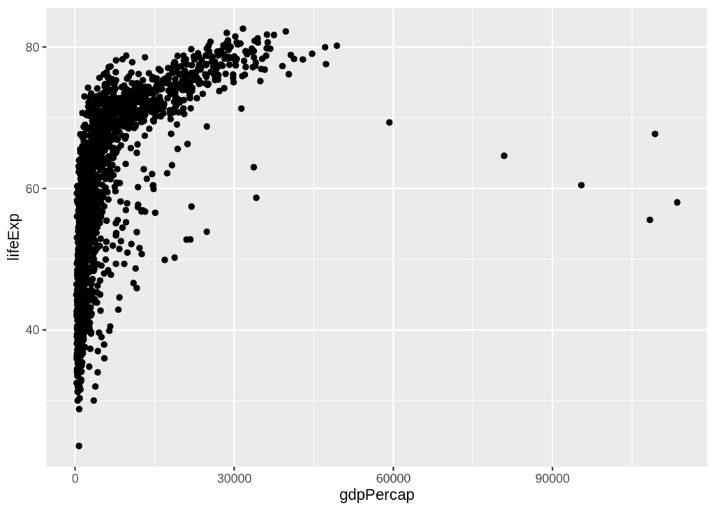

```r
p + geom_point()
```

To summarize what we did above, there were 3 steps we went through. First, tell `ggplot()` what our data is. Second, add `mapping = aes()` to map our variables to the plot. And, third, choose a geom. In this case our geom was `geom_point()` which created the points/data layer on our plot. A fourth step could have included adding a scale, legend, title or some other element to the graph. These are typically referred to as labs.

2. Modify the above plot so that the variables it draws on are life expectancy and population. Then, use a comment to annotate the code and mark each of the 3 parts described above.

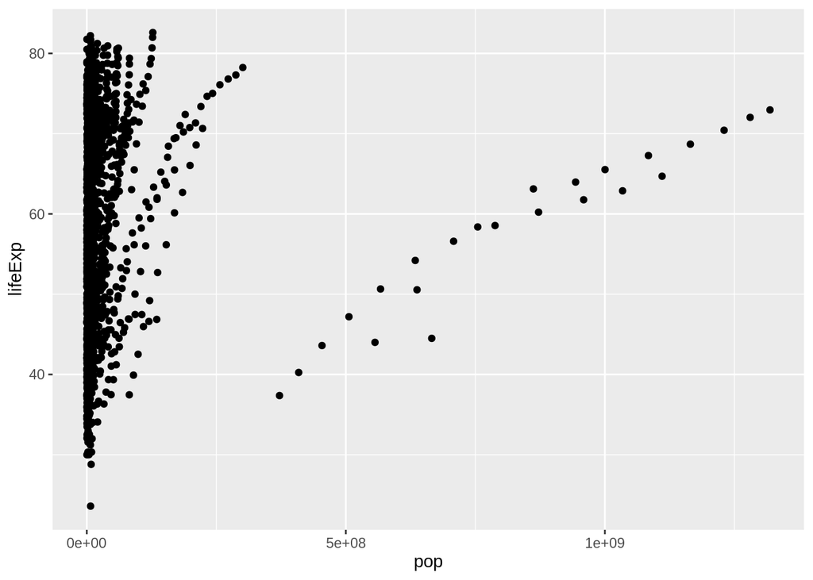

```r
p <- ggplot(data = gapminder) #which dataset we want to use
p <- ggplot(data = gapminder, mapping = aes(x = pop, y = lifeExp)) #to map the lifeExp and population
p + geom_point() #to plot on a scatterplot
```

We can make this plot even more complex. Adding another value, color, to `aes()` we can change the color of each dot to correspond to a year. We also might want to rename the x and y-axis so that the labels have a more useful description of the variable. We can do so using the labs function.

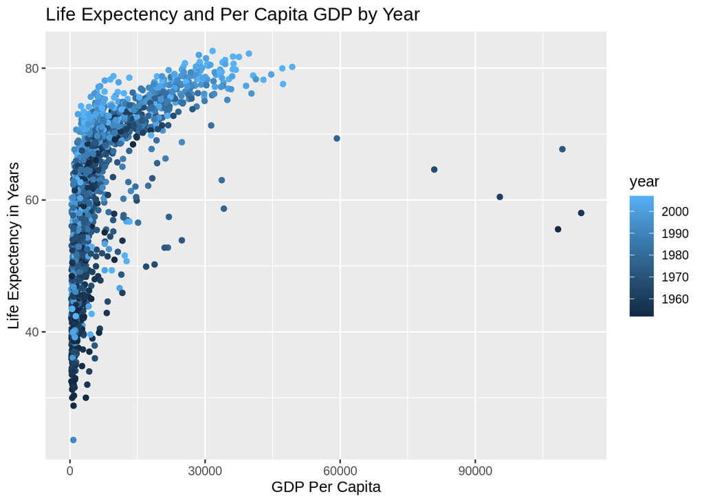

```r
ggplot(data = gapminder, mapping = aes(x = gdpPercap, y=lifeExp, color=year)) + geom_point() + labs(x="GDP Per Capita", y="Life Expectency in Years", title="Life Expectency and Per Capita GDP by Year")
```

> this is beautiful, by the way!!

3. Using the same plot above, can you edit the code to add a trend line? (Hint: You’ll need to add another geom)

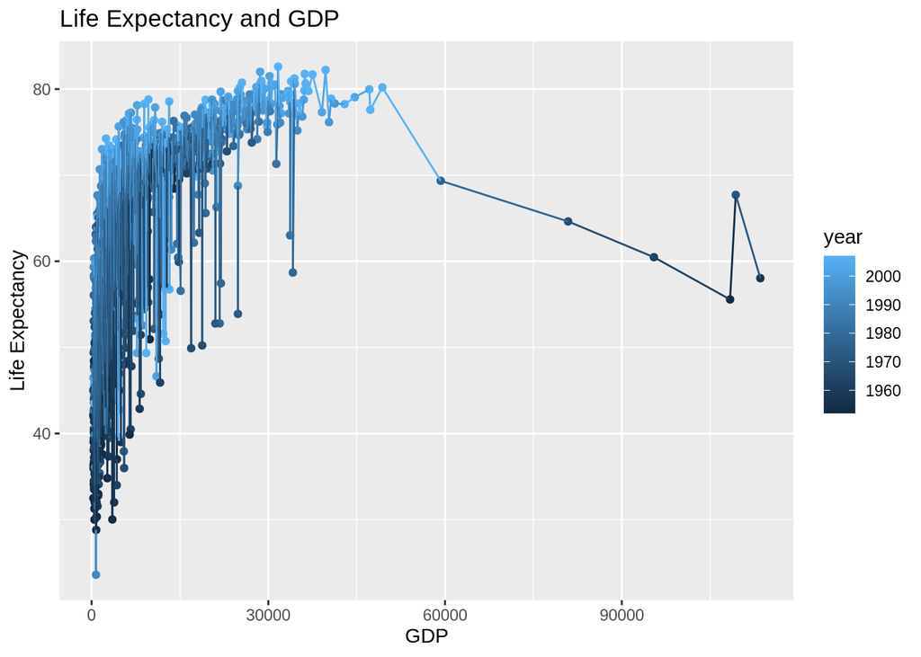

```r
ggplot(gapminder, aes(x = gdpPercap, y = lifeExp, color = year)) + geom_point() +
  labs(x = "GDP", y = "Life Expectancy", title = "Life Expectancy and GDP") +
  geom_line()
```

4. The file below contains data about the population of cities in 1930 and their recreation expenditures. Can you create a scatter plot from this data?

```r
rec <- read.csv(file = "https://raw.githubusercontent.com/regan008/DigitalMethodsData/main/raw/Recreation-Expenditures.csv")
```

The `geom_point()` function allows us to create scatterplots but its not the only geom within `ggplot2()`.

### Histogram

A histogram is a graph used to represent the frequency distribution of a few data points of one variable. Histograms often classify data into various “bins” or “range groups” and count how many data points belong to each of those bins.

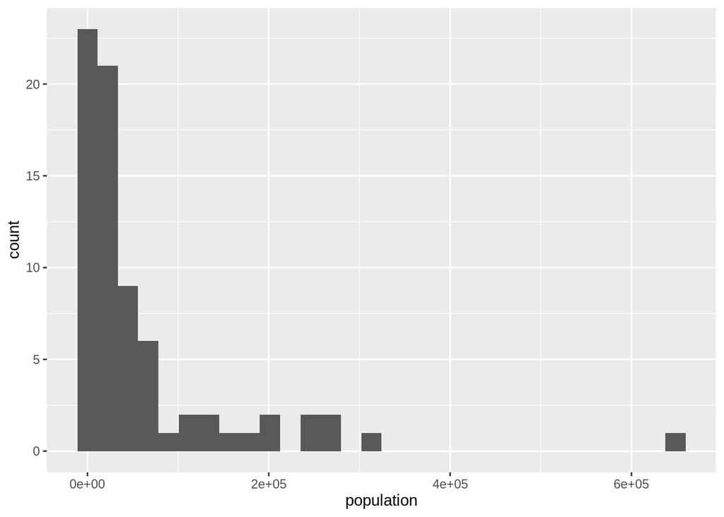

```r
recreational.data <- read.csv("https://raw.githubusercontent.com/regan008/DigitalMethodsData/main/raw/Recreation-Expenditures.csv")

ggplot(recreational.data, aes(x = population)) +
  geom_histogram()
```

5. Use the Boston Women’s voters dataset to create a histogram of the age of voters.

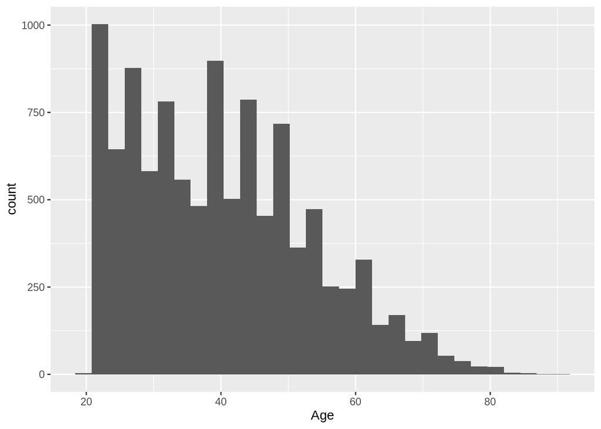

```r
data("BostonWomenVoters") #to load dataset

ggplot(BostonWomenVoters, aes(x = Age)) +
  geom_histogram()
```

6. By default, `geom_histogram()` is choosing the number of bins. Can you change the number of bins or the bin width? (Hint: How might you look up the options for this function?)

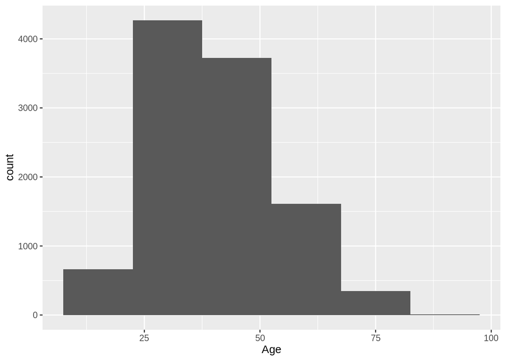

```r
ggplot(BostonWomenVoters, aes(x = Age)) +
  geom_histogram(binwidth = 15)
```

7. Explain, what does changing the number of bins do?

### Barplots

A barplot (or barchart) is one of the most common types of graphic. Whereas a histogram shows the number of entries in each “bin” - a bar chart shows the relationship between a numeric and a categorical variable. Each entity in the categorical variable is represented as a bar. The size of the bar represents its numeric value.

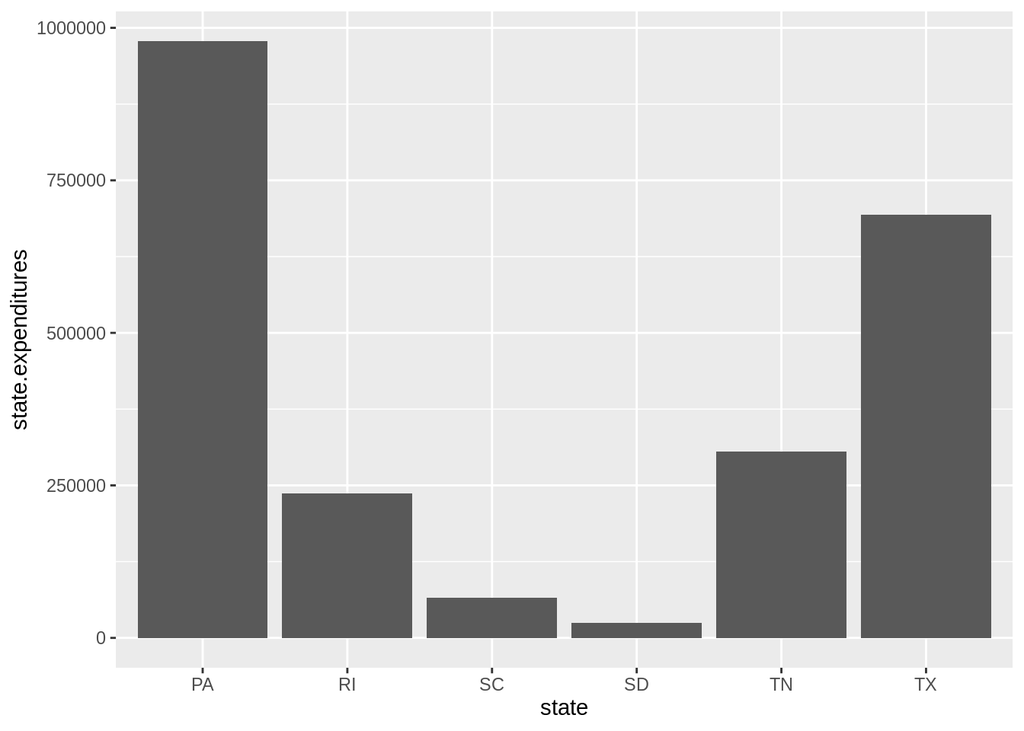

```r
sc.rec <- recreational.data %>% group_by(state) %>% summarize(state.expenditures = sum(total_expenditures))
ggplot(sc.rec, aes(x = state, y = state.expenditures )) +
  geom_col()
```

8. Using the `gayguides` data, create a bar chart that shows the number of locations in 1980 in South Carolina, Georgia, and North Carolina.

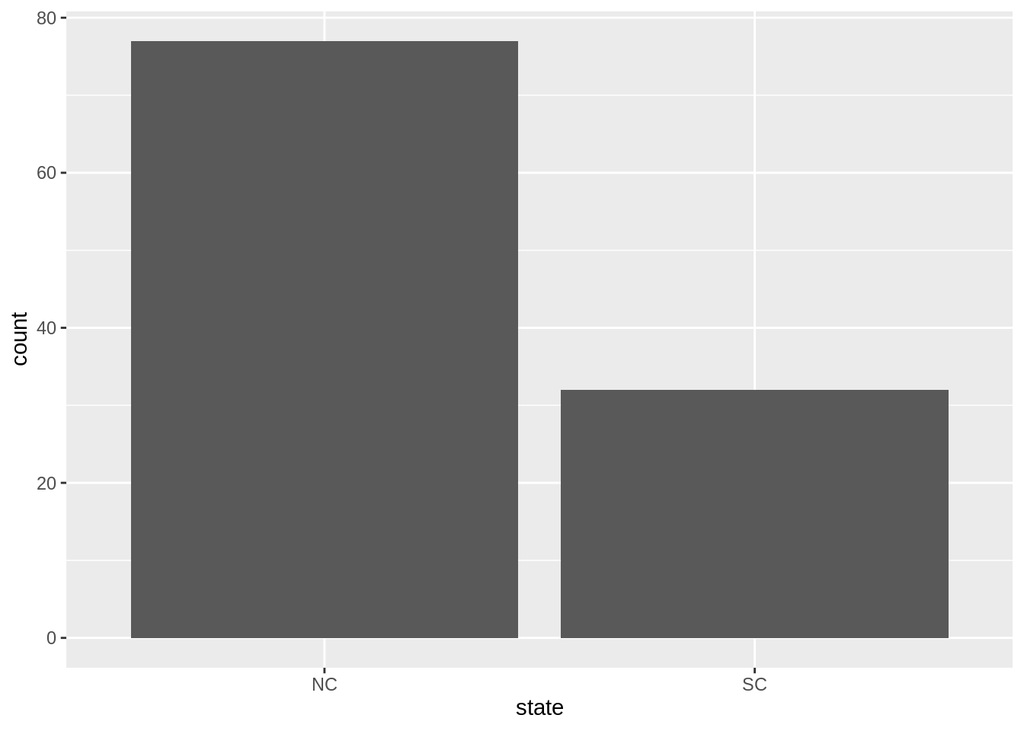

```r
data("gayguides") #load dataset

guideschart <- gayguides %>% #name the variable
  filter(Year == 1980) %>%
  filter(state == "SC" | state == "NC" | state == "Georgia") %>%
  group_by(state) %>%
  summarize(count = n())

ggplot(guideschart, aes(x = state, y = count)) +
  geom_col() #geom col since we can look at the height of the data
```

9. Using the `gayguides` data, plot the number of religious institutions in each state.

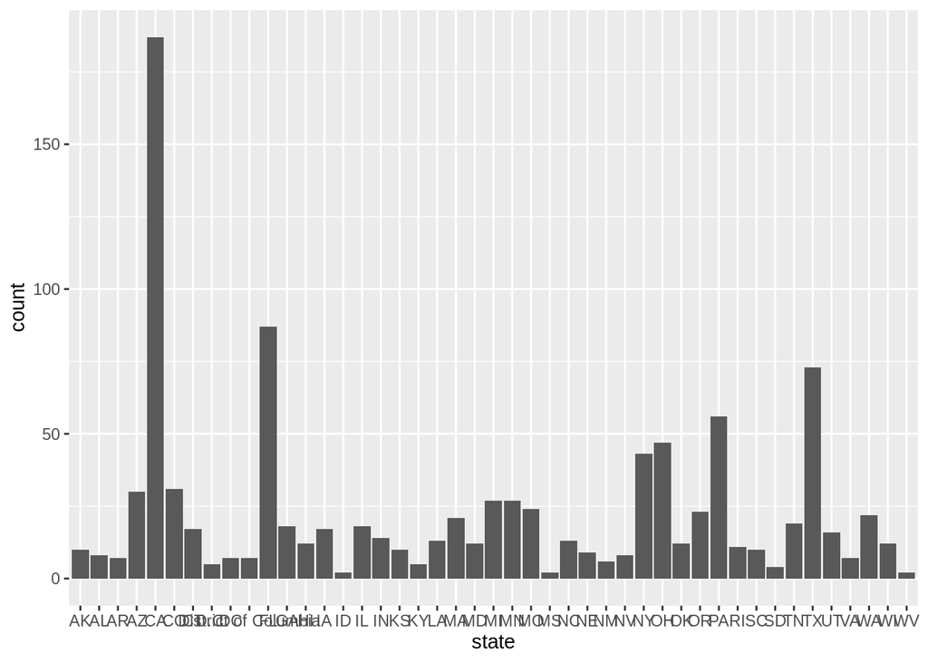

```r
religious.data <- gayguides %>% #name the variable
  filter(type == "Religious Institution") %>%
  group_by(state) %>%
  summarize(count = n())

ggplot(religious.data, aes(x = state, y = count)) +
  geom_col() #using the same bar chart
```

10. Formulate a question based on a dataset of your choice. That question should be something that would be appropriately answered by a bar chart. What is the question you want to explore?

> Which country had the most housewives? (Boston Women’s Dataset)
11. Now write the code to answer that question and use comments (`#`) to explain your thinking as you go.

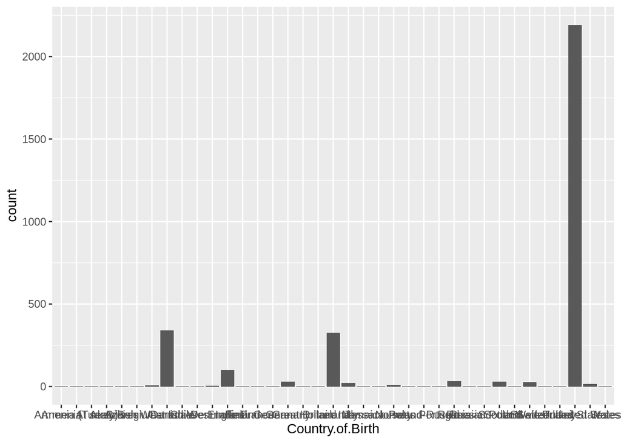

```r
housewives <- BostonWomenVoters %>% #name the variable
  filter(Occupation == "Housewife") %>% #search by housewife
  group_by(Country.of.Birth) %>% #and where they're from
  summarize(count = n())

ggplot(housewives, aes(x = Country.of.Birth, y = count)) +
  geom_col()
```

> The United States had the most housewives. Canada comes in second.